# Differential expression analysis

Angelo Limeta

September 12, 2024

## Load Libraries

```r
library(AnnotationDbi)
library(org.Hs.eg.db)
library(biomaRt)

library(tidyverse)
```

```r
library(ggrepel)
library(tidyHeatmap)
library(edgeR)
library(piano)

select = dplyr::select
```

## Plot settings

```r
# Use colourblind-friendly colours
friendly_cols <- dittoSeq::dittoColors()

# Set theme
custom_theme <-
  list(
    scale_fill_manual(values = friendly_cols),
    scale_color_manual(values = friendly_cols),
    theme_bw() +
      theme(
        panel.border = element_blank(),
        axis.line = element_line(),
        panel.grid.major = element_line(linewidth = 0.2),
        panel.grid.minor = element_line(linewidth = 0.1),
        text = element_text(size = 12),
        legend.position = "bottom",
        strip.background = element_blank(),
        axis.title.x = element_text(margin = margin(t = 10, r = 10, b = 10, l = 10)),
        axis.title.y = element_text(margin = margin(t = 10, r = 10, b = 10, l = 10)),
        axis.text.x = element_text(angle = 30, hjust = 1, vjust = 1)
      )
  )
```

## Load data

```r
tbl_meta <- readRDS(file = "../../results/processed_data/tbl_meta.rds")
tbl_rna <- readRDS(file = "../../results/processed_data/tbl_rna.rds")
```

## Preprocessing

Let’s begin by combining counts and metadata and add annotations per gene

```r
# Merge metadata and counts and annotate transcripts with gene symbol
tbl_full <- tbl_meta %>%
  right_join(tbl_rna, by = "sample_id") %>%
  mutate(
    # Remove the version numbers from the transcript IDs
    target_id_clean = str_remove(target_id, "\\..*"),

    # Map transcript IDs to gene symbols
    symbol = mapIds(
      org.Hs.eg.db,
      keys = target_id_clean,
      keytype = "ENSEMBLTRANS",
      column = "SYMBOL",
      multiVals = "first"
    )
  )
```

```r
tbl_gene_level <-
  tbl_full %>%
  filter(!is.na(symbol)) %>%
  group_by(symbol, sample_id) %>%
  summarise(
    est_counts = sum(est_counts, na.rm = TRUE),
  ) %>%
  ungroup() %>%
  left_join(tbl_meta, by = "sample_id") %>%
  select(sample_id,method,condition,symbol,est_counts) %>%
  mutate(condition = as.factor(as.character(condition)))
head(tbl_gene_level)
```

| sample_id | method | condition | symbol | est_counts |
| --- | --- | --- | --- | --- |
| S42155 | rna_seq | scr | A3GALT2 | 0 |
| S42156 | rna_seq | kd | A3GALT2 | 0 |
| S45028 | rna_seq | scr | A3GALT2 | 0 |
| S45030 | rna_seq | kd | A3GALT2 | 0 |
| S42155 | rna_seq | scr | A4GNT | 0 |
| S42156 | rna_seq | kd | A4GNT | 0 |

```r
# Check number of genes:
tbl_gene_level %>% select(symbol) %>% distinct() %>% nrow()
```

```
## [1] 12823
```

## Differential expression

We will begin by performing the standard steps in the edgeR pipeline

```r
# Summarize counts by gene and sample
tbl_counts <- tbl_gene_level %>%
  select(sample_id, symbol, est_counts) %>%
  pivot_wider(names_from = sample_id, values_from = est_counts) # Wide format

# Prepare the design matrix
design <- tbl_gene_level %>%
  select(sample_id, condition) %>%
  distinct() %>%
  mutate(condition = factor(condition, levels = c("scr", "kd"),ordered = T))  # Ensure "scr" is baseline

# Convert tibble to matrix for edgeR
count_matrix <- tbl_counts %>%
  column_to_rownames("symbol") %>%  # Set the gene symbols as row names
  as.matrix()

# Ensure sample order matches between the design and counts matrix
stopifnot(all(colnames(count_matrix) == design$sample_id))

# Create DGEList object
dge <- DGEList(counts = count_matrix, group = design$condition)

# Filter out lowly expressed genes
# Keep genes with at least 1 count per million (CPM) in at least 2 samples
keep <- filterByExpr(dge)
dge <- dge[keep, , keep.lib.sizes=FALSE]

# Normalize the data using TMM normalization
dge <- calcNormFactors(dge)

# Estimate dispersions
dge <- estimateDisp(dge, design = model.matrix(~condition, data = design))

# Fit the GLM
fit <- glmFit(dge, design = model.matrix(~condition, data = design))

# Perform likelihood ratio test to find differentially expressed genes
lrt <- glmLRT(fit)

# Summarize the results
top_genes <- topTags(lrt, n = Inf)  # n = Inf returns all genes

# Add FDR column for significance cutoff
top_genes_tbl <- as_tibble(top_genes$table) %>%
  mutate(gene = rownames(top_genes$table)) %>%
  arrange(FDR)  # Sort by FDR (False Discovery Rate)

# Output results
print(head(top_genes_tbl, 20))  # View top 20 differentially expressed genes
```

```
## # A tibble: 20 × 6
##    logFC logCPM    LR   PValue      FDR gene
##    <dbl>  <dbl> <dbl>    <dbl>    <dbl> <chr>
##  1 -2.77  10.1  172.  2.61e-39 5.66e-36 TACSTD2
##  2 -3.39   7.86 172.  3.21e-39 5.66e-36 CLDN7
##  3 -1.75   7.23  74.1 7.25e-18 8.51e-15 SOX9
##  4 -1.46   8.21  71.0 3.61e-17 3.18e-14 ARHGAP23
##  5 -2.49   5.80  69.9 6.10e-17 4.30e-14 EPHA1
##  6 -3.05   4.90  65.4 6.00e-16 3.52e-13 NCCRP1
##  7 -2.23   6.64  61.6 4.16e-15 2.09e-12 TMEM30B
##  8 -3.85   3.20  57.4 3.64e-14 1.61e-11 KRTAP2-3
##  9 -4.68   2.66  56.5 5.51e-14 2.16e-11 PRSS22
## 10 -2.62   5.70  54.8 1.31e-13 4.63e-11 ANKRD22
## 11  2.07   5.54  51.7 6.43e-13 2.06e-10 CLEC2B
## 12 -2.69   8.04  49.4 2.13e-12 6.24e-10 SPRR1B
## 13 -4.03   3.22  47.8 4.66e-12 1.16e- 9 KRT23
## 14  2.29   5.72  47.8 4.78e-12 1.16e- 9 C1R
## 15 -1.35   7.47  47.7 4.94e-12 1.16e- 9 CDC42BPG
## 16 -1.17   8.62  44.6 2.38e-11 5.23e- 9 CAMK2N1
## 17 -2.12   5.25  44.3 2.84e-11 5.90e- 9 ONECUT3
## 18 -3.01   3.70  42.6 6.55e-11 1.28e- 8 SOWAHB
## 19 -1.51  12.6   42.5 7.10e-11 1.32e- 8 S100A14
## 20  1.30   7.79  42.1 8.71e-11 1.53e- 8 CFB
```

```r
# Save results to a file
write_csv(top_genes_tbl, file = "../../results/tables/differential_expression_results.csv")
```

Let’s do some routine visualizations. We can begin with a volcano plot of the genes.

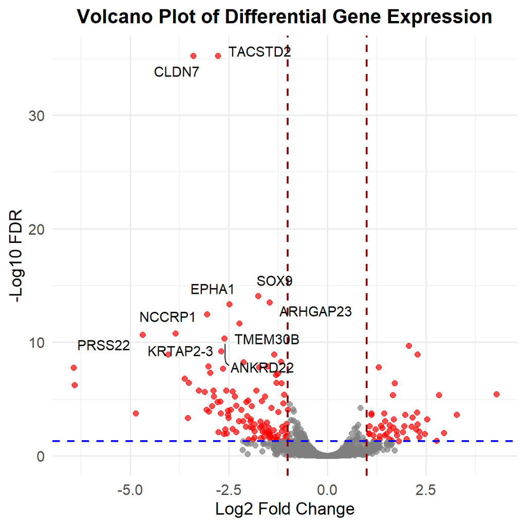

```r
# Define fold change and FDR thresholds
fold_change_threshold <- 1
fdr_threshold <- 0.05

p_volcano <-
  top_genes_tbl %>%
  ggplot(aes(x = logFC, y = -log10(FDR), label = gene)) +

  # Add points with color by significance
  geom_point(aes(color = FDR < fdr_threshold & abs(logFC) > fold_change_threshold),
             alpha = 0.7, size = 2) +

  # Vertical lines for fold-change thresholds
  geom_vline(xintercept = c(-fold_change_threshold, fold_change_threshold),
             linetype = "dashed", color = "darkred", size = 0.8) +

  # Horizontal line for FDR threshold
  geom_hline(yintercept = -log10(fdr_threshold),
             linetype = "dashed", color = "blue", size = 0.8) +

  # Highlight top 10 most significant genes with labels
  geom_text_repel(
    data = top_genes_tbl %>% arrange(FDR) %>% slice(1:10),
    aes(label = gene),
    size = 4,
    box.padding = 0.5,
    point.padding = 0.5,
    max.overlaps = 10,
    segment.color = 'black',  # Black line for clear connection
    segment.size = 0.5,       # Thinner lines for clarity
    segment.curvature = -0.2, # Slightly curved segments for aesthetics
    segment.angle = 90        # Make the lines stand out vertically
  ) +

  # Customize color scale
  scale_color_manual(values = c("gray50", "red")) +

  # Titles and labels
  labs(
    title = "Volcano Plot of Differential Gene Expression",
    x = "Log2 Fold Change",
    y = "-Log10 FDR",
    color = "Significant"
  ) +

  # Customize theme
  theme_minimal(base_size = 14) +
  theme(
    legend.position = "none",  # Hide legend for simplicity
    plot.title = element_text(hjust = 0.5, size = 16, face = "bold"),
    axis.title = element_text(size = 14),
    axis.text = element_text(size = 12)
  )
p_volcano
```

```r
# Save plot to file
ggsave(plot = p_volcano,filename = "../../results/figures/dge_volcano.pdf")
```

Let’s make a heatmap of the top differentially expressed genes

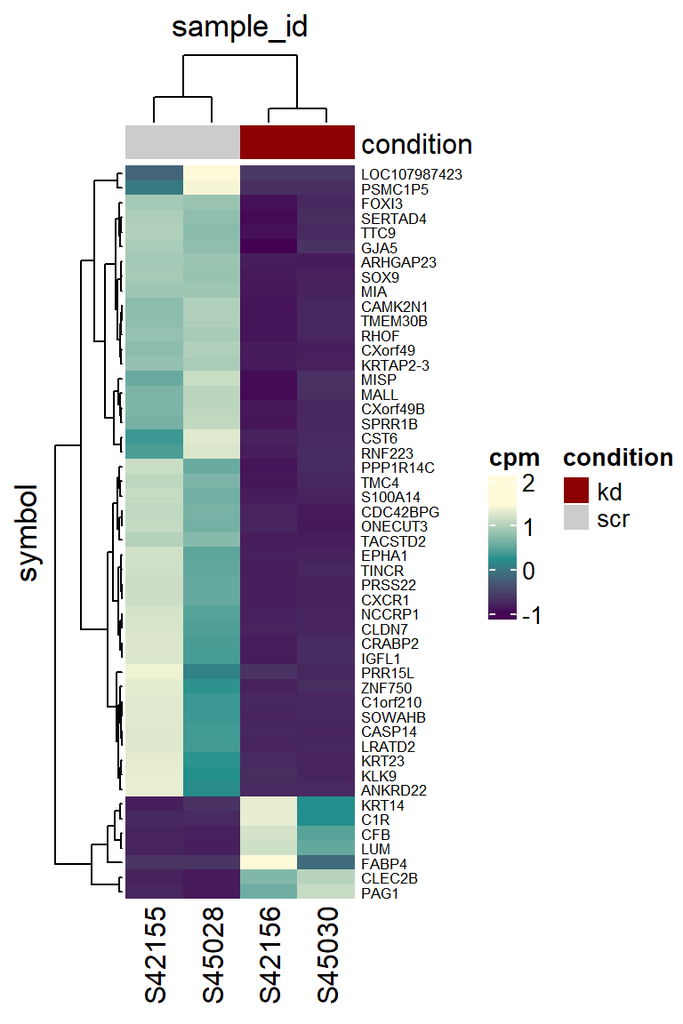

```r
# Extract TMM-normalized counts (CPM) from the DGEList object
cpm_tmm <- cpm(dge, normalized.lib.sizes = TRUE, log = FALSE)

# Convert the CPM matrix to a tibble
tbl_cpm <- as_tibble(cpm_tmm, rownames = "symbol") %>%
  pivot_longer(cols = -symbol, names_to = "sample_id", values_to = "cpm")

# Join with metadata to include condition and method information
tbl_cpm_with_meta <- tbl_cpm %>%
  left_join(tbl_meta, by = "sample_id")

# Select top 50 genes for example purposes
top_50_genes <- top_genes_tbl %>%
  arrange(FDR) %>%
  slice_head(n=50) %>%
  pull(gene)

tbl_top_50 <- tbl_cpm_with_meta %>%
  filter(symbol %in% top_50_genes)

# Create heatmap using tidyheatmap
p_heatmap <-
  tbl_top_50 %>%
  mutate(condition = as.character(condition)) %>%
  heatmap(
    .row = symbol,
    .column = sample_id,
    .value = cpm,
    scale = "row"
  ) %>%
  add_tile(.column = condition, palette = c("grey80","darkred"))

p_heatmap
```

```r
# Save plot to file
save_pdf(.heatmap = p_heatmap,filename = "../../results/figures/dge_heatmap.pdf",width = 4,height = 6)
```

Plot top 12 genes

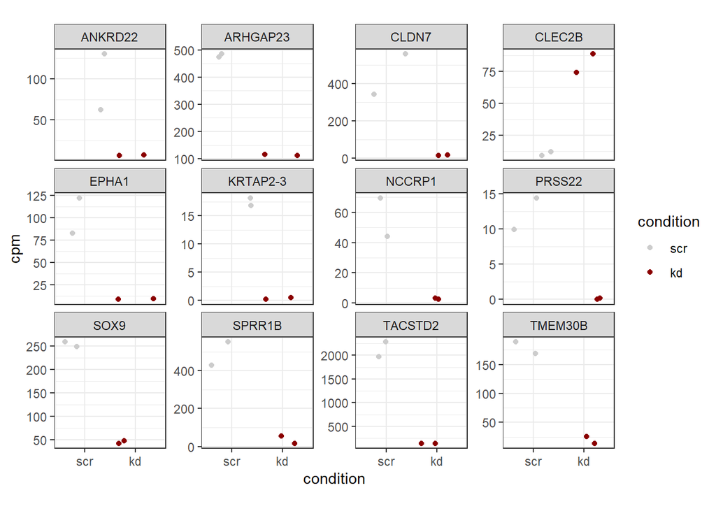

```r
# Select top 12 genes
top_12_genes <- top_genes_tbl %>%
  arrange(FDR) %>%
  slice_head(n=12) %>%
  pull(gene)

# Filter and plot in facets
p_top12_dge <-
  tbl_cpm_with_meta %>%
  filter(symbol %in% top_12_genes) %>%
  ggplot(aes(x = condition,y = cpm, color = condition)) +
  geom_jitter() +
  facet_wrap(vars(symbol),scales = "free_y") +
  theme_bw() +
  theme(aspect.ratio = 1) +
  scale_color_manual(values = c("grey80","darkred"))

p_top12_dge
```

```r
# Save plot to file
ggsave(plot = p_top12_dge, filename = "../../results/figures/dge_top12genes.pdf")
```

I guess that this is breast cancer cells, but let’s verify the cell type.

**Let’s check the expression of these genes:**

- **ESR1**: Encodes the estrogen receptor, primarily involved in the regulation of estrogen-responsive genes.
- **PGR**: Encodes the progesterone receptor, which is involved in the response to progesterone hormone signaling.
- **ERBB2**: Encodes the HER2 protein, a member of the epidermal growth factor receptor family, often associated with cell growth and differentiation.
- **GATA3**: A transcription factor crucial for the development and differentiation of luminal cells in breast tissue.
- **FOXA1**: A transcription factor that plays a role in estrogen receptor signaling and breast cancer cell differentiation.
- **KRT18**: Encodes keratin 18, a marker for luminal epithelial cells in various tissues, including breast tissue.
- **KRT14**: Encodes keratin 14, often found in basal epithelial cells, playing a role in structural integrity.

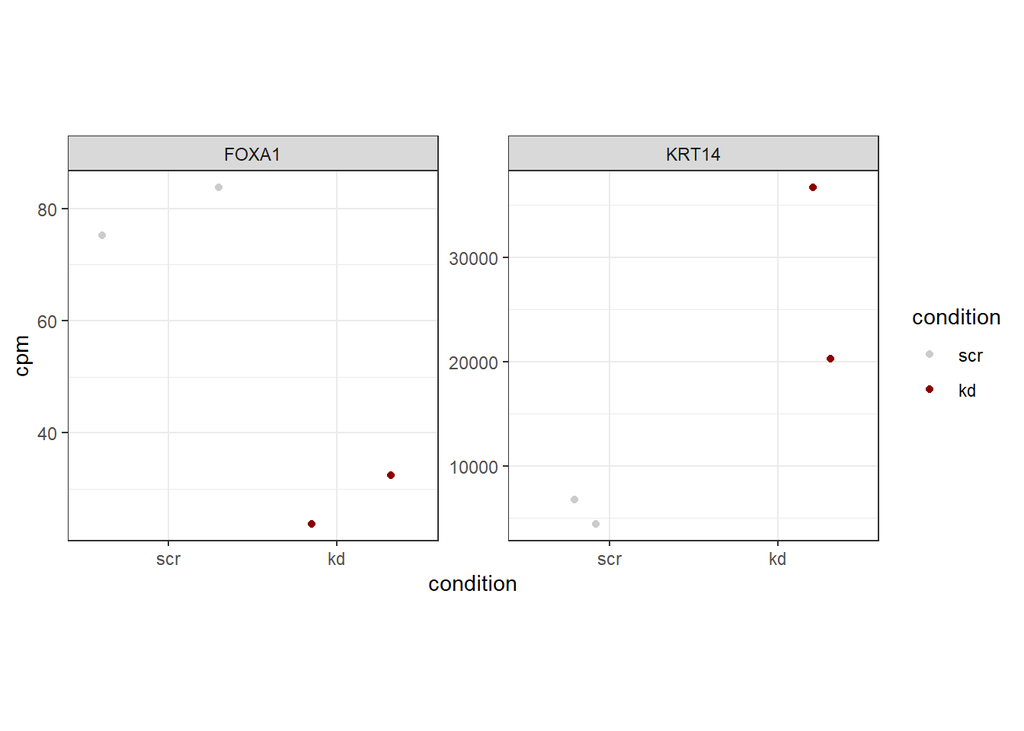

```r
brca_markers <- c("ESR1", "PGR", "ERBB2", "GATA3", "FOXA1", "KRT18","KRT14")

p_markers_brca <-
  tbl_cpm_with_meta %>%
  filter(symbol %in% brca_markers) %>%
  ggplot(aes(x = condition,y = cpm, color = condition)) +
  geom_jitter() +
  facet_wrap(vars(symbol),scales = "free_y") +
  theme_bw() +
  theme(aspect.ratio = 1) +
  scale_color_manual(values = c("grey80","darkred"))

p_markers_brca
```

```r
# Save plot to file
ggsave(plot = p_markers_brca, filename = "../../results/figures/dge_brca_markers.pdf")
```

Only **FOXA1** and **KRT14** were detected in the dataset. The absence of **ESR1**, **PGR**, and **ERBB2** suggests that key markers related to hormone receptor status are not expressed. This lack of receptor markers, alongside the presence of **KRT14**, which is associated with basal-like characteristics, hints that these cells could potentially be from **triple-negative breast cancer (TNBC)**.

Now let’s focus on the potential knockdown, let’s see the raw values for the top 2 genes:

- **CLDN7** (Claudin-7): Claudins are essential components of tight junctions, which regulate paracellular transport in epithelial tissues. CLDN7 has been linked to cancer progression and metastasis, and its altered expression has been observed in breast cancer, including TNBC (https://doi.org/10.21873%2Finvivo.11238).
- **TACSTD2** (Tumor-associated calcium signal transducer 2, aka Trop2): TACSTD2 is a cell surface glycoprotein implicated in cell proliferation and survival. It has been linked to poor prognosis in several cancers, including breast cancer, and plays a role in promoting tumor growth and metastasis in aggressive subtypes like TNBC (https://doi.org/10.1038/s41523-021-00341-6).

```r
tbl_cpm_with_meta %>%
  filter(symbol %in% c("CLDN7","TACSTD2"))
```

| symbol | sample_id | cpm | method | condition |
| --- | --- | --- | --- | --- |
| CLDN7 | S42155 | 558.60049 | rna_seq | scr |
| CLDN7 | S42156 | 14.78220 | rna_seq | kd |
| CLDN7 | S45028 | 340.96900 | rna_seq | scr |
| CLDN7 | S45030 | 17.36171 | rna_seq | kd |
| TACSTD2 | S42155 | 2281.27253 | rna_seq | scr |
| TACSTD2 | S42156 | 140.55757 | rna_seq | kd |
| TACSTD2 | S45028 | 1967.90917 | rna_seq | scr |
| TACSTD2 | S45030 | 140.13925 | rna_seq | kd |

Based on the drastic reduction in TACST2 expression, and it’s somewhat more clear role in metastasis, I’d think that this would be the target gene in the knockdown experiment.

Either way, let’s also check the expression of all claudins to check their expression levels.

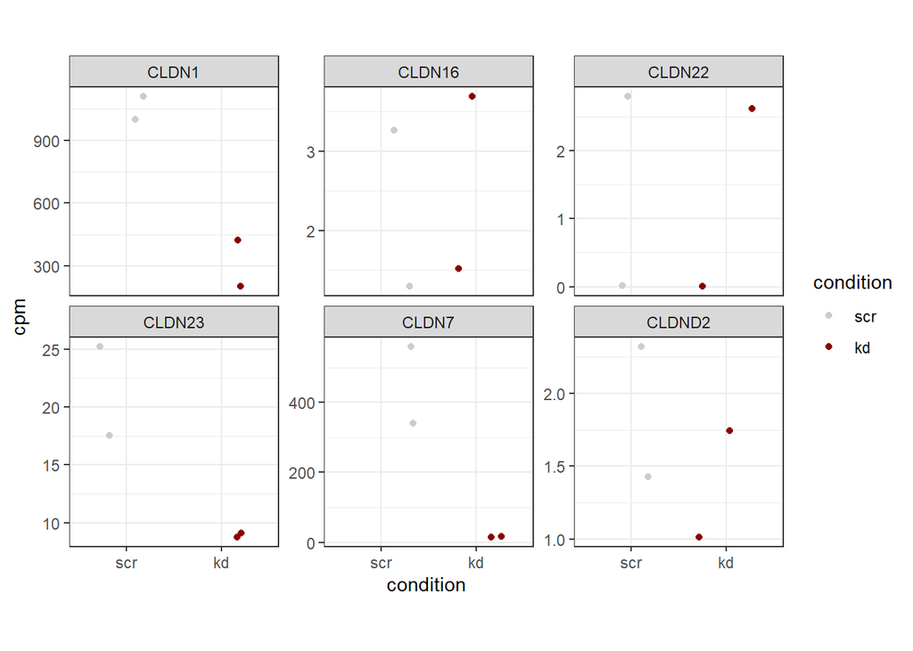

```r
p_claudins <-
  tbl_cpm_with_meta %>%
  filter(grepl("CLDN",symbol)) %>%
  ggplot(aes(x = condition,y = cpm, color = condition)) +
  geom_jitter() +
  facet_wrap(vars(symbol),scales = "free_y") +
  theme_bw() +
  theme(aspect.ratio = 1) +
  scale_color_manual(values = c("grey80","darkred"))

p_claudins
```

```r
# Save plot to file
ggsave(plot = p_claudins, filename = "../../results/figures/dge_claudins.pdf")
```

Looks like lots of these aren’t even expressed.

Now we can check processes that are changed using gene set enrichment with Piano

```r
# Load gene set (Cancer hallmarks)
hallmarks_gsc = loadGSC(file = "../../data/gene_sets/h.all.v2024.1.Hs.symbols.gmt")

# Extract FDR adjusted pvalues and log2 fold-changes
padj = top_genes_tbl %>%
  pull(FDR)

log2fc = top_genes_tbl %>%
  pull(logFC)

names(padj) = top_genes_tbl %>%
  pull(gene)

names(log2fc) = top_genes_tbl %>%
  pull(gene)
cat("p-values \n")
```

```
## p-values
```

```r
head(padj)
```

```
##      TACSTD2        CLDN7         SOX9     ARHGAP23        EPHA1       NCCRP1
## 5.664396e-36 5.664396e-36 8.513822e-15 3.177159e-14 4.300192e-14 3.523645e-13
```

```r
cat("\nlog2-FC \n")
```

```
##
## log2-FC
```

```r
head(log2fc)
```

```
##   TACSTD2     CLDN7      SOX9  ARHGAP23     EPHA1    NCCRP1
## -2.771824 -3.393038 -1.752350 -1.464944 -2.488658 -3.051063
```

```r
# Run Piano
gsaRes <- runGSA(padj,
                 log2fc,
                 gsc=hallmarks_gsc,
                 ncpus=8,
                 signifMethod = "geneSampling",
                 nPerm = 10000
                 )
```

```
## Running gene set analysis:
```

```
## Checking arguments...done!
```

```
## Final gene/gene-set association: 733 genes and 50 gene sets
```

```
##   Details:
```

```
##   Using all 3524 gene-level statistics for significance estimation
```

```
##   Removed 3651 genes from GSC due to lack of matching gene statistics
```

```
##   Removed 0 gene sets containing no genes after gene removal
```

```
##   Removed additionally 0 gene sets not matching the size limits
```

```
##   Loaded additional information for 50 gene sets
```

```
## Adjusting for multiple testing...done!
```

Plot gene set analysis heatmap

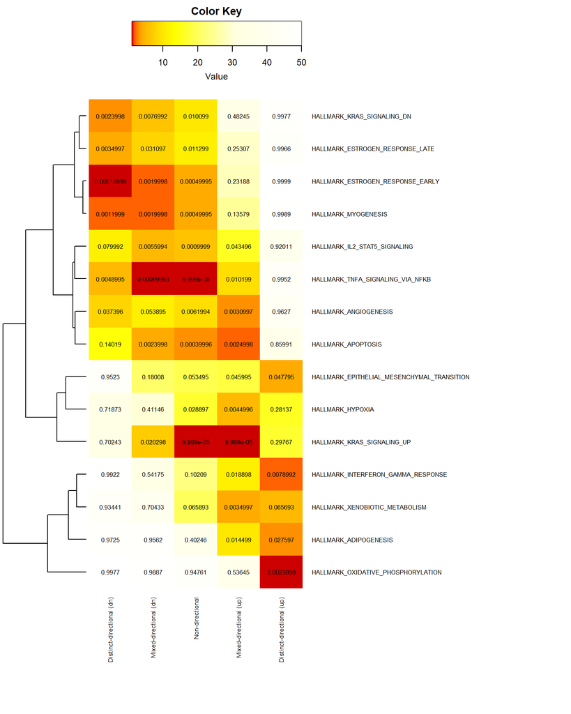

```r
GSAheatmap(gsaRes,cex = 0.8,ncharLabel = Inf)
```

Looks like we have downregulation of:

- **TNFalpha signaling**
- **KRAS signaling**
- **Estrogen response**

and upregulation of:

- **EMT**
- **KRAS SIGNALING**
- **INFgamma respose**
- **Adipogenessis**
- **Oxidative phosphorylation**

Looks like this knockdown seems to promote metastasis!

# Save data objects of interest

```r
saveRDS(object = tbl_cpm_with_meta,file = "../../results/processed_data/tbl_cp_with_meta.rds")
saveRDS(object = top_genes_tbl,file = "../../results/processed_data/tbl_top_genes.rds")
```